# Introduction

This is predominantly taken from the PyMVPA tutorial. I thought going through line-by-line might be a bit more helpful than just seeing the webpage, and allows us to take a closer look at what is going on.

The code is found at: http://www.pymvpa.org/examples/hyperalignment.html

The data is found at: http://data.pymvpa.org/datasets/hyperalignment_tutorial_data/

### Load data

```python
from mvpa2.suite import *
verbose.level = 2
filepath = 'hyperalignment_tutorial_data.hdf5.gz'
ds_all = h5load(filepath)   # Uses a built in utility
```

So, what is `ds_all`? It is a list which contains 10 datasets. But what is a dataset?

- A dataset is the basic container in PyMVPA
- It serves as the primary form of data storage, but also as a common container for results returned by most algorithms

In PyMVPA is a two dimensional array, where the first axis is the samples axis, and second axis represents features

```python
data = [[ 1, 1, -1],
... [ 2, 0, 0],
... [ 3, 1, 1],
... [ 4, 0, -1]]
ds = Dataset(data)
ds.shape
```

```
(4, 3)
```

```python
print(ds.nfeatures)
print(ds.nsamples)
```

```
3
4
```

# Recap

If the dataset is a matrix, then **each row is an observation** and each column represents a variable.

```python
import numpy as np
m_ds = Dataset(np.random.random((3, 4, 2, 3)))
```

# Question

What is the numper of features?

```python
m_ds.nfeatures
```

```
4
```

# Why Datasets?

Sometimes, we want more information of a sample than just the value of features. A dataset contains 3 types of attributes:

1. sample attribute
   - `ds.sa['some_attr'] = [0,1,1,3]`
   - `ds.sa['some_attr'].value`
   - **stored as `Collectable` for various reasons**
2. feature attribute
   - `ds.fa['my_fav'] = [0, 1, 0]`
   - `ds.fa['responsible'] = ['me', 'you', 'nobody']`
3. dataset attribute
   - `ds.a['pointless'] = np.rand((4,4))`
   - No limits (different from previous examples)

# Mappers

This is a pretty involved concept. They represent particular kinds of transformations and can be seen as a protocol of what has been done. A very important part of mappers is that they allow a reverse transformation, if it is possible

```python
ds = dataset_wizard(np.ones((5, 4, 3)))
print(ds.shape)
print('mapper' in ds.a)
print(ds.a.mapper)
```

```
(5, 12)
True
<FlattenMapper>
```

```python
# Reverse mapping
print(ds)
orig_data = ds.a.mapper.reverse(ds.samples)
print(orig_data.shape)
```

```
<Dataset: 5x12@float64, <a: mapper>>
(5, 4, 3)
```

**NOTE** the previous examples applies to both mappers and ChainMappers

## Exporting Data

While saving data is h5, when we want to go backwards an project data back onto the brain. This requires that the dataset has a `imghdr` attribute. For the below example, `revtest` is a vector that was generated after some processing

```
nimg = map2nifti(ds,revtest)
nimg.to_filename('mytest.nii.gz')
```

# Hyperalignment Tutorial

Heading back with some groundwork layed out, we can now follow along with the code

```python
# zscore all datasets individually
_ = [zscore(ds) for ds in ds_all]
# inject the subject ID into all datasets
for i, sd in enumerate(ds_all):
    sd.sa['subject'] = np.repeat(i, len(sd))
```

Note: I do not know what the `UT` attribute is, and that there are 7 categories.

## Recap

Recalling from last weeks paper

> Sixteen images from one category were shown in each block, and subjects performed a 1-back repitition detection task. [...] One block stimulus was presented in each of eight runs

# Analysis

The tutorial uses an SVM classifier and use one-way ANOVA to select the `nf` highest scoring features

```python
# use same classifier
clf = LinearCSVMC()

# feature selection helpers
nf = 100
fselector = FixedNElementTailSelector(nf, tail='upper',
                                      mode='select', sort=False)
sbfs = SensitivityBasedFeatureSelection(OneWayAnova(), fselector,
                                        enable_ca=['sensitivities'])
# create classifier with automatic feature selection
fsclf = FeatureSelectionClassifier(clf, sbfs)
```

## Within Subject Classification

Taken from tutorial

We start off by running a cross-validated classification analysis for every subject’s dataset individually. Data folding will be performed by leaving out one run to serve as the testing dataset. ANOVA-based features selection will be performed automatically on training dataset and applied to testing dataset.

```python
wsc_start_time = time.time()
cv = CrossValidation(fsclf,
                     NFoldPartitioner(attr='chunks'),
                     errorfx=mean_match_accuracy)
# store results in a sequence
wsc_results = [cv(sd) for sd in ds_all]
wsc_results = vstack(wsc_results)
verbose(2, " done in %.1f seconds" % (time.time() - wsc_start_time,))
print('The shape is: ' + str(wsc_results.shape))
```

```
   done in 1.0 seconds
The shape is: (80, 1)
```

## Between-subject classification using anatomically aligned data

For between-subject classification with MNI-aligned voxels, we can stack up all individual datasets into a single one, as (anatomical!) feature correspondence is given. The cross-validation analysis using the feature selection classifier will automatically perform the desired ANOVA-based feature selection on every training dataset partition. However, data folding will now be done by leaving out a complete subject for testing.

```python
ds_mni = vstack(ds_all)
mni_start_time = time.time()
cv = CrossValidation(fsclf,
                     NFoldPartitioner(attr='subject'),
                     errorfx=mean_match_accuracy)
bsc_mni_results = cv(ds_mni)
verbose(2, "done in %.1f seconds" % (time.time() - mni_start_time,))
print('The shape is: ' + str(bsc_mni_results.shape))
```

```
  done in 0.6 seconds
The shape is: (10, 1)
```

## Between-subject classification with Hyperalignment(TM)

To avoid introducing circularity problems to the analysis, we perform leave-one-run-out data folding manually, and train Hyperalignment only on the training dataset partitions. Subsequently, we will apply the derived transformation to the full datasets, stack them up across individual subjects, as before, and run the classification analysis. ANOVA-based feature selection is done in the same way as before (but also manually)

### An Aside

In the next code block, we will see `chunks` used. Looking at the manual, we see:

> Moreover, for a cross-validation procedure we also need to partition the full dataset into, presumably, independent chunks

So, how is this done? Ideally, the chunks indicates that data came from different acquistion sessions (but at leas not the same run). The manual indicates that the simplest way to create this attribute is the following way

```python
# directory that contains the data files
data_path = os.path.join(tutorial_data_path, 'haxby2001')
attr_fname = os.path.join(data_path, 'sub001',
             'BOLD', 'task001_run001', 'attributes.txt')
attr = SampleAttributes(attr_fname)
print(len(attr.targets))
print(np.unique(attr.targets))
print(len(attr.chunks))
print(np.unique(attr.chunks))
```

[output not shown]

```python
hyper_start_time = time.time()
bsc_hyper_results = []
# same cross-validation over subjects as before
cv = CrossValidation(clf, NFoldPartitioner(attr='subject'),
                     errorfx=mean_match_accuracy)

# leave-one-run-out for hyperalignment training
nruns = len(ds_all[0].UC)
for test_run in range(nruns):
    # split in training and testing set
    ds_train = [sd[sd.sa.chunks != test_run, :] for sd in ds_all]
    ds_test = [sd[sd.sa.chunks == test_run, :] for sd in ds_all]

    # manual feature selection for every individual dataset in the list
    anova = OneWayAnova()
    fscores = [anova(sd) for sd in ds_train]
    featsels = [StaticFeatureSelection(fselector(fscore)) for fscore in fscores]
    ds_train_fs = [fs.forward(sd) for fs, sd in zip(featsels, ds_train)]


    # Perform hyperalignment on the training data with default parameters.
    # Computing hyperalignment parameters is as simple as calling the
    # hyperalignment object with a list of datasets. All datasets must have the
    # same number of samples and time-locked responses are assumed.
    # Hyperalignment returns a list of mappers corresponding to subjects in the
    # same order as the list of datasets we passed in.


    hyper = Hyperalignment()
    hypmaps = hyper(ds_train_fs)

    # Applying hyperalignment parameters is similar to applying any mapper in
    # PyMVPA. We start by selecting the voxels that we used to derive the
    # hyperalignment parameters. And then apply the hyperalignment parameters
    # by running the test dataset through the forward() function of the mapper.

    ds_test_fs = [fs.forward(sd) for fs, sd in zip(featsels, ds_test)]
    ds_hyper = [h.forward(sd) for h, sd in zip(hypmaps, ds_test_fs)]

    # Now, we have a list of datasets with feature correspondence in a common
    # space derived from the training data. Just as in the between-subject
    # analyses of anatomically aligned data we can stack them all up and run the
    # crossvalidation analysis.

    ds_hyper = vstack(ds_hyper)
    # zscore each subject individually after transformation for optimal
    # performance
    zscore(ds_hyper, chunks_attr='subject')
    res_cv = cv(ds_hyper)
    bsc_hyper_results.append(res_cv)

bsc_hyper_results = hstack(bsc_hyper_results)
verbose(2, "done in %.1f seconds" % (time.time() - hyper_start_time,))
```

```
  done in 3.3 seconds
```

## Comparing Results

This is just taken from the code again, and replicates results in paper

```python
nsubjs = len(ds_all)
verbose(1, "Average classification accuracies:")
verbose(2, "within-subject: %.2f +/-%.3f"
        % (np.mean(wsc_results),
           np.std(wsc_results) / np.sqrt(nsubjs - 1)))
verbose(2, "between-subject (anatomically aligned): %.2f +/-%.3f"
        % (np.mean(bsc_mni_results),
           np.std(np.mean(bsc_mni_results, axis=1)) / np.sqrt(nsubjs - 1)))
verbose(2, "between-subject (hyperaligned): %.2f +/-%.3f" \
        % (np.mean(bsc_hyper_results),
           np.std(np.mean(bsc_hyper_results, axis=1)) / np.sqrt(nsubjs - 1)))
```

```
 Average classification accuracies:
  within-subject: 0.57 +/-0.063
  between-subject (anatomically aligned): 0.42 +/-0.035
  between-subject (hyperaligned): 0.62 +/-0.053
```

# Interlude

## Processed Data

```python
import os
from mvpa2.base.hdf5 import h5load
os.chdir('/mnt/data/smazurchuk/haxby_tomb_raiders/')
os.listdir('raiders/derivatives/swaroop-hyper/task002/BOLD')
```

```
['bold_hyper_sw1_mni_vt.hdf5.gz',
 'bold_surfslhyper_sw1_radius20_lr32_hr128_part2_featsel0.7.hdf5.gz',
 'bold_surfslhyper_sw1_radius20_lr32_hr128_full_featsel0.7.hdf5.gz',
 'bold_hyper_sw1_mni_gray_large_part1_hyperaligned.hdf5.gz',
 'bold_hyper_sw1_mni_gray_large.hdf5.gz']
```

From the README in the top-level directory, we are told:

- `sub001/BOLD/task002/bold_sw1_stc_reg_despike_dt_bp_mni.nii.gz`

  Pre-processed data for subject 1, **all runs concatenated**, in MNI space, after linear anatomical alignment
- `aligned/BOLD/task002/bold_surfslhyper_sw1_radius20_lr32_hr128_full_featsel0.7.hdf5.gz`

  Hyperalignment projections estimated per each subject.

```python
pth = 'raiders/derivatives/swaroop-hyper/task002/BOLD/bold_hyper_sw1_mni_gray_large.hdf5.gz'
bold_surfslhyper = h5load(pth)
```

```python
bold_surfslhyper.keys()
```

```
['mask', 'ds', 'subjs', 'fname']
```

```python
ds = bold_surfslhyper['ds']
```

```python
len(ds)
print(ds[0].shape)
```

```
(2662, 61831)
```

```python
ds[0].summary
```

[output not shown]

## Next Steps

Within MVPA, we can make plots pretty readily. However, if we want to visualize the information on a brain surface or do some other analysis in image space, we can switch to the rest of the NiPy ecosystem

```python
# Scatter plot two voxel time series
import matplotlib.pyplot as plt
print(ds[0].shape)
print(ds[4].shape)
```

```
(2662, 61831)
(2662, 61831)
```

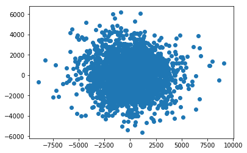

```python
plt.scatter(ds[0][:,100],ds[4][:,100])
```

```python
# Switch to other format
gg = map2nifti(ds[0]) # Now a NIIMG Object
import nilearn as nil
random_volume = nil.image.index_img(gg,10)
random_volume.to_filename('temp_delete.nii.gz')
```

# Next Notebook!

(unfortunately ... )